Created on Wed Nov 17 10:25:58 2021

Made by Niels Aalund Krogsgaard

```python
import numpy as np
import pandas as pd
import seaborn as sns
import matplotlib.pyplot as plt
import os
import requests
import io
```

# Exercises and objectives

1) Load the magnetoencephalographic recordings and do some initial plots to understand the data  
2) Do logistic regression to classify pairs of PAS-ratings  
3) Do a Support Vector Machine Classification on all four PAS-ratings

REMEMBER: In your report, make sure to include code that can reproduce the answers requested in the exercises below (**MAKE A KNITTED VERSION**)  
REMEMBER: This is Assignment 3 and will be part of your final portfolio

## EXERCISE 1

Load the magnetoencephalographic recordings and do some initial plots to understand the data

The files `megmag_data.npy` and `pas_vector.npy` can be downloaded here (http://laumollerandersen.org/data_methods_3/megmag_data.npy) and here (http://laumollerandersen.org/data_methods_3/pas_vector.npy)

### 1)

Load `megmag_data.npy` and call it `data` using `np.load`. You can use `join`, which can be imported from `os.path`, to create paths from different string segments

```python
import requests
import io

response = requests.get('http://laumollerandersen.org/data_methods_3/megmag_data.npy')
response.raise_for_status()
data = np.load(io.BytesIO(response.content))
```

#### 1 1) i.

The data is a 3-dimensional array. The first dimension is number of repetitions of a visual stimulus , the second dimension is the number of sensors that record magnetic fields (in Tesla) that stem from neurons activating in the brain, and the third dimension is the number of time samples. How many repetitions, sensors and time samples are there?

```python
print(data.shape)
```

```
(682, 102, 251)
```

There are 682 reptitions, 102 sensors and 251 time samples.

#### 1 1) ii.

The time range is from (and including) -200 ms to (and including) 800 ms with a sample recorded every 4 ms. At time 0, the visual stimulus was briefly presented. Create a 1-dimensional array called `times` that represents this.

```python
times = np.arange(-200, 801, 4)
```

#### 1 1) iii.

Create the sensor covariance matrix $\Sigma_{XX}$: $$\Sigma_{XX} = \frac 1 N \sum_{i=1}^N XX^T$$ $N$ is the number of repetitions and $X$ has $s$ rows and $t$ columns (sensors and time), thus the shape is $X_{s\times t}$. Do the sensors pick up independent signals? (Use `plt.imshow` to plot the sensor covariance matrix)

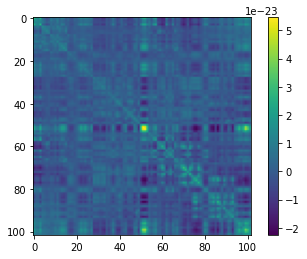

```python
N = len(data[:,0,0])

cov = np.sum(np.array([data[i,:,:] @ data[i,:,:].T for i in range(N)]), axis = 0)/N

plt.imshow(cov)
plt.colorbar()
```

Most of the colors are in the region around 0, so it seems like the sensors are picking up independent signals, however some areas are a bit troubling with high covariance. But it is hard to conclude on the basis of visual inspection.

#### 1 1) iv.

Make an average over the repetition dimension using `np.mean` - use the `axis` argument. (The resulting array should have two dimensions with time as the first and magnetic field as the second with sensor as the first and time as the second)

```python
rep_mean = np.mean(data, axis = 0)
```

#### 1 1) v.

Plot the magnetic field (based on the average) as it evolves over time for each of the sensors (a line for each) (time on the x-axis and magnetic field on the y-axis). Add a horizontal line at $y = 0$ and a vertical line at $x = 0$ using `plt.axvline` and `plt.axhline`

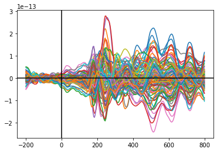

```python
for i in range(len(rep_mean[:,0])):
    plt.plot(times, rep_mean[i,:])
plt.axvline(0, c = "black")
plt.axhline(0, c = "black")
```

#### 1 1) vi.

Find the maximal magnetic field in the average. Then use `np.argmax` and `np.unravel_index` to find the sensor that has the maximal magnetic field.

```python
max_mag = np.unravel_index(np.argmax(rep_mean), rep_mean.shape)
print(max_mag)
```

```
(73, 112)
```

Since python indexing starts at 0, this means that sensor number 74 is the one that achieves the highest magnetic field at one point in time when averaged over repetitions. It does this at timepoint 112, which is at positive 248 ms.

#### 1 1) vii.

Plot the magnetic field for each of the repetitions (a line for each) for the sensor that has the maximal magnetic field. Highlight the time point with the maximal magnetic field in the average (as found in 1.1.v) using `plt.axvline`

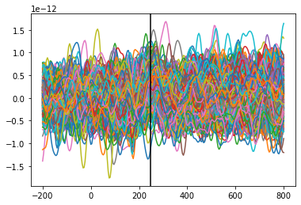

```python
for i in range(len(data[:,73,0])):
    plt.plot(times, data[i,73,:])
plt.axvline(times[112], c = "black")
```

#### 1 1) viii.

Describe in your own words how the response found in the average is represented in the single repetitions. But do make sure to use the concepts *signal* and *noise* and comment on any differences on the range of values on the y-axis

We found that the sensor, who had the highest average activation for all repititions was the sensor 74 at 248 ms. However, as can be seen in the plot of all repetitions for that particular sensor, there is a large amount of variation or noise throughout the time frame. It would be hard to visually detect an overall signal or differences between the individual repetitions in this plot.

### 2)

Now load `pas_vector.npy` (call it `y`). PAS is the same as in Assignment 2, describing the clarity of the subjective experience the subject reported after seeing the briefly presented stimulus

```python
response = requests.get('http://laumollerandersen.org/data_methods_3/pas_vector.npy')
response.raise_for_status()
y = np.load(io.BytesIO(response.content))
```

#### 1 2) i.

Which dimension in the `data` array does it have the same length as?

```python
print(y.shape)
print(data.shape)
```

```
(682,)
(682, 102, 251)
```

The vector consisting of the PAS ratings has the same length as the first dimnesion in the data array, which is the repetition dimension.

#### 1 2) ii.

Now make four averages (As in Exercise 1.1.iii), one for each PAS rating, and plot the four time courses (one for each PAS rating) for the sensor found in Exercise 1.1.vi

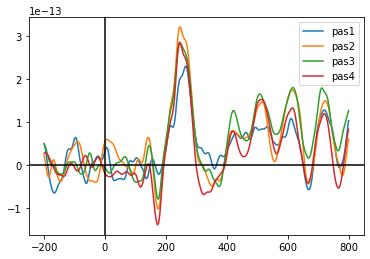

```python
idx_1 = np.argwhere(y == 1)
data_pas_1 = np.mean(np.squeeze(data[idx_1,73,:]), axis = 0)
idx_2 = np.argwhere(y == 2)
data_pas_2 = np.mean(np.squeeze(data[idx_2,73,:]), axis = 0)
idx_3 = np.argwhere(y == 3)
data_pas_3 = np.mean(np.squeeze(data[idx_3,73,:]), axis = 0)
idx_4 = np.argwhere(y == 4)
data_pas_4 = np.mean(np.squeeze(data[idx_4,73,:]), axis = 0)

plt.plot(times, data_pas_1, label = "pas1")
plt.plot(times, data_pas_2, label = "pas2")
plt.plot(times, data_pas_3, label = "pas3")
plt.plot(times, data_pas_4, label = "pas4")
plt.axvline(0, c = "black")
plt.axhline(0, c = "black")
plt.legend()
```

#### 1 2) iii.

Notice that there are two early peaks (measuring visual activity from the brain), one before 200 ms and one around 250 ms. Describe how the amplitudes of responses are related to the four PAS-scores. Does PAS 2 behave differently than expected?

At a PAS score of 1 the subject did not subjectively perceive anything, so it might make sense that the amplitude is lower, since we would not expect much activation, when "nothing" is there to be perceived or processed. PAS 2 is the one with the highest average activation around time 250 ms. This is somewhat surprising since a PAS score of 2 would also entail that the person had not seen the stimuli clearly. But perhaps this could be rationalised by thinking of it as the brain have to process the uncertainty of the perceived stimuli, while this is not needed with higher PAS ratings. PAS 4 has the highest amplitude before 200 ms, which could come from early visual processing which is more activated with a more clear perceived stimulus. However, we do not know what area of the brain sensor 74 is measuring, so it is actually not possible to conclude anything regarding what processes lie behind the activation.

## Exercise 2

Do logistic regression to classify pairs of PAS-ratings

### 1)

Now, we are going to do Logistic Regression with the aim of classifying the PAS-rating given by the subject.

#### 2 1) i.

We'll start with a binary problem - create a new array called `data_1_2` that only contains PAS responses 1 and 2. Similarly, create a `y_1_2` for the target vector

```python
idx = np.argwhere((y == 1) | (y == 2))
data_1_2 = np.squeeze(data[idx,:,:])
y_1_2 = np.squeeze(y[idx])
```

#### 2 1) ii.

Scikit-learn expects our observations (`data_1_2`) to be in a 2d-array, which has samples (repetitions) on dimension 1 and features (predictor variables) on dimension 2. Our `data_1_2` is a three-dimensional array. Our strategy will be to collapse our two last dimensions (sensors and time) into one dimension, while keeping the first dimension as it is (repetitions). Use `np.reshape` to create a variable `X_1_2` that fulfils these criteria.

```python
X_1_2 = data_1_2.reshape(214,-1)
```

#### 2 1) iii.

Import the `StandardScaler` and scale `X_1_2`

```python
from sklearn.preprocessing import StandardScaler

scaler = StandardScaler()
X_1_2_1 = scaler.fit_transform(X_1_2)
```

#### 2 1) iv.

Do a standard `LogisticRegression` - can be imported from `sklearn.linear_model` - make sure there is no `penalty` applied

```python
from sklearn.linear_model import LogisticRegression

log_model = LogisticRegression(penalty='none', random_state=12)
log_model.fit(X_1_2_1, y_1_2)
```

```
LogisticRegression(penalty='none', random_state=12)
```

#### 2 1) v.

Use the `score` method of `LogisticRegression` to find out how many labels were classified correctly. Are we overfitting? Besides the score, what would make you suspect that we are overfitting?

```python
accuracy = log_model.score(X_1_2_1, y_1_2)
print(accuracy)
```

```
1.0
```

The accuracy is at 100%, which does seem a bit troubeling. It could indicate overfitting, but we have no way of knowing since the data is not divided into training and test. Besides the accuracy score, adding no penalty makes the risk of overfitting quite high since we have 25602 features in our model.

#### 2 1) vi.

Now apply the *L1* penalty instead - how many of the coefficients (`.coef_`) are non-zero after this?

```python
#for the penalty l1 to work, we need to change solver to be liblinear or saga.
log_model_l1 = LogisticRegression(penalty='l1', solver = 'liblinear', random_state=(12))
log_model_l1.fit(X_1_2_1, y_1_2)
print(len(log_model_l1.coef_[0]) - sum(log_model_l1.coef_[0] == 0))
```

```
272
```

272 coefficients are non-zero after applying the L1 penalty (plus a liblinear solver and random_state of 12).

#### 2 1) vii.

Create a new reduced $X$ that only includes the non-zero coefficients - show the covariance of the non-zero features (two covariance matrices can be made; $X_{reduced}X_{reduced}^T$ or $X_{reduced}^TX_{reduced}$ (you choose the right one)) . Plot the covariance of the features using `plt.imshow`. Compared to the plot from 1.1.iii, do we see less covariance?

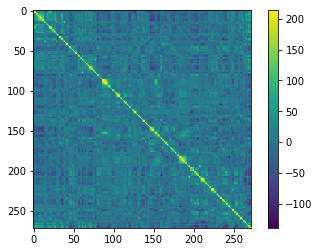

```python
idx = np.where(log_model_l1.coef_[0] != 0)
X_1_2_2 = np.squeeze(X_1_2_1[:, idx])

cov = X_1_2_2.T @ X_1_2_2

plt.imshow(cov)
plt.colorbar()
```

Since there are more colours corresponding to the range around zero in this plot, I would say that there is a bit less covariance in this plot compared to the one from 1.1.iii. However, it is still hard to conclude anything visually.

### 2)

Now, we are going to build better (more predictive) models by using cross-validation as an outcome measure

#### 2 2) i.

Import `cross_val_score` and `StratifiedKFold` from `sklearn.model_selection`

```python
from sklearn.model_selection import cross_val_score, StratifiedKFold
```

#### 2 2) ii.

To make sure that our training data sets are not biased to one target (PAS) or the other, create `y_1_2_equal`, which should have an equal number of each target. Create a similar `X_1_2_equal`. The function `equalize_targets_binary` in the code chunk associated with Exercise 2.2.ii can be used. Remember to scale `X_1_2_equal`!

```python
#just checking the actual number of each PAS rating

unique, counts = np.unique(y_1_2, return_counts=True)
un_co = dict(zip(unique,counts))
print(un_co)
```

```
{1: 99, 2: 115}
```

```python
def equalize_targets_binary(data, y):
    np.random.seed(7)
    targets = np.unique(y) ## find the number of targets
    if len(targets) > 2:
        raise NameError("can't have more than two targets")
    counts = list()
    indices = list()
    for target in targets:
        counts.append(np.sum(y == target)) ## find the number of each target
        indices.append(np.where(y == target)[0]) ## find their indices
    min_count = np.min(counts)
    # randomly choose trials
    first_choice = np.random.choice(indices[0], size=min_count, replace=False)
    second_choice = np.random.choice(indices[1], size=min_count,replace=False)

    # create the new data sets
    new_indices = np.concatenate((first_choice, second_choice))
    new_y = y[new_indices]
    new_data = data[new_indices, :, :]

    return new_data, new_y
```

```python
X_1_2_equal, y_1_2_equal = equalize_targets_binary(data_1_2, y_1_2)

X_1_2_equal_re = X_1_2_equal.reshape(X_1_2_equal.shape[0], -1)
#scaling
scaler = StandardScaler()
X_1_2_equal_1 = scaler.fit_transform(X_1_2_equal_re)
```

#### 2 2) iii.

Do cross-validation with 5 stratified folds doing standard `LogisticRegression` (See Exercise 2.1.iv)

```python
#StratifiedKFold can be used without cross_val_score by the following way

log_model_skf = LogisticRegression(penalty='none')

skf = StratifiedKFold(n_splits = 5)
skf_accu = []

for train, test in skf.split(X_1_2_equal_1, y_1_2_equal):
    x_train, x_test = X_1_2_equal_1[train,:], X_1_2_equal_1[test,:]
    y_train, y_test = y_1_2_equal[train], y_1_2_equal[test]
    log_model_skf.fit(x_train,y_train)
    skf_accu.append(log_model_skf.score(x_test, y_test))

print(skf_accu, np.mean(skf_accu).round(5))
```

```
[0.65, 0.5, 0.45, 0.6410256410256411, 0.4358974358974359] 0.53538
```

```python
#if we actually must use the StratifiedKFold function inside cross_val_score, this is how to do it (as can be seen, it produces the same results)
log_model_cv = LogisticRegression(penalty='none')
cv = StratifiedKFold(n_splits = 5)
cv_score = cross_val_score(log_model_cv, X_1_2_equal_1, y_1_2_equal, cv = cv)
print(cv_score, np.mean(cv_score).round(5))
```

```
[0.65       0.5        0.45       0.64102564 0.43589744] 0.53538
```

```python
#since StratifiedKFold is the standard cross validate method of cross_val_score, we actually do not need to use it, so this will be my choice of method moving on

log_model_cv = LogisticRegression(penalty='none')
cv_score = cross_val_score(log_model_cv, X_1_2_equal_1, y_1_2_equal, cv=5)
print(cv_score, np.mean(cv_score).round(5))
```

```
[0.65       0.5        0.45       0.64102564 0.43589744] 0.53538
```

#### 2 2) iv.

Do L2-regularisation with the following `Cs= [1e5, 1e1, 1e-5]`. Use the same kind of cross-validation as in Exercise 2.2.iii. In the best-scoring of these models, how many more/fewer predictions are correct (on average)?

```python
log_model_cv_l2 = LogisticRegression(penalty='l2', C = 1e5, random_state = 12)
cv_score = cross_val_score(log_model_cv_l2, X_1_2_equal_1, y_1_2_equal, cv=5)
print(cv_score, np.mean(cv_score))

log_model_cv_l2 = LogisticRegression(penalty='l2', C = 1e1, random_state = 12)
cv_score = cross_val_score(log_model_cv_l2, X_1_2_equal_1, y_1_2_equal, cv=5)
print(cv_score, np.mean(cv_score))

log_model_cv_l2 = LogisticRegression(penalty='l2', C = 1e-5, random_state = 12)
cv_score = cross_val_score(log_model_cv_l2, X_1_2_equal_1, y_1_2_equal, cv=5)
print(cv_score, np.mean(cv_score))
```

```
[0.65       0.5        0.45       0.64102564 0.43589744] 0.5353846153846155
[0.625      0.525      0.425      0.58974359 0.46153846] 0.5252564102564102
[0.65       0.625      0.575      0.53846154 0.58974359] 0.5956410256410256
```

#### 2 2) v.

Instead of fitting a model on all `n_sensors * n_samples` features, fit a logistic regression (same kind as in Exercise 2.2.iv (use the `C` that resulted in the best prediction)) for **each** time sample and use the same cross-validation as in Exercise 2.2.iii. What are the time points where classification is best? Make a plot with time on the x-axis and classification score on the y-axis with a horizontal line at the chance level (what is the chance level for this analysis?)

```python
X_1_2_equal, y_1_2_equal = equalize_targets_binary(data_1_2, y_1_2)
log_model_cv_time_indi = LogisticRegression(penalty='l2', C = 1e-5, random_state = 12)

cv_scores = np.zeros((X_1_2_equal.shape[2], 5))
mean_cv_scores = np.zeros(X_1_2_equal.shape[2])

for i in range(X_1_2_equal.shape[2]):
    x_data = X_1_2_equal[:,:,i]
    scaler = StandardScaler()
    x_data = scaler.fit_transform(x_data)
    cv_scores[i,:] = cross_val_score(log_model_cv_time_indi, x_data[:,:], y_1_2_equal, cv=5)
    mean_cv_scores[i] = np.mean(cv_scores[i,:])

print("Binary classification of PAS rating (1 or 2) is best at", times[np.argmax(mean_cv_scores)], "ms")
```

```
Binary classification of PAS rating (1 or 2) is best at 232 ms
```

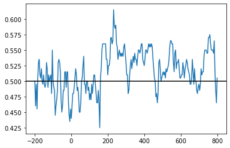

```python
plt.plot(times, mean_cv_scores)
plt.axhline(y = 0.5, c = "black")
```

#### 2 2) vi.

Now do the same, but with L1 regression - set `C=1e-1` - what are the time points when classification is best? (make a plot)?

```python
X_1_2_equal, y_1_2_equal = equalize_targets_binary(data_1_2, y_1_2)
log_model_cv_time_indi = LogisticRegression(penalty='l1', C = 1e-1, solver = "liblinear")

cv_scores = np.zeros((X_1_2_equal.shape[2], 5))
mean_cv_scores = np.zeros(X_1_2_equal.shape[2])

for i in range(X_1_2_equal.shape[2]):
    x_data = X_1_2_equal[:,:,i]
    scaler = StandardScaler()
    x_data = scaler.fit_transform(x_data)
    cv_scores[i,:] = cross_val_score(log_model_cv_time_indi, x_data[:,:], y_1_2_equal, cv=5)
    mean_cv_scores[i] = np.mean(cv_scores[i,:])

print("Binary classification of PAS rating (1 or 2) is best at", times[np.argmax(mean_cv_scores)], "ms")
```

```
Binary classification of PAS rating (1 or 2) is best at 244 ms
```

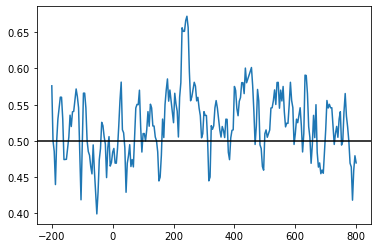

```python
plt.plot(times, mean_cv_scores)
plt.axhline(y = 0.5, c = "black")
```

#### 2 2) vii.

Finally, fit the same models as in Exercise 2.2.vi but now for `data_1_4` and `y_1_4` (create a data set and a target vector that only contains PAS responses 1 and 4). What are the time points when classification is best? Make a plot with time on the x-axis and classification score on the y-axis with a horizontal line at the chance level (what is the chance level for this analysis?)

```python
idx = np.argwhere((y == 1) | (y == 4))
data_1_4 = np.squeeze(data[idx,:,:])
y_1_4 = y[idx]

X_1_4_equal, y_1_4_equal = equalize_targets_binary(data_1_4, y_1_4)
log_model_cv_time_indi = LogisticRegression(penalty='l1', C = 1e-1, solver = "liblinear")

cv_scores = np.zeros((X_1_4_equal.shape[2], 5))
mean_cv_scores = np.zeros(X_1_4_equal.shape[2])

for i in range(X_1_4_equal.shape[2]):
    x_data = X_1_4_equal[:,:,i]
    scaler = StandardScaler()
    x_data = scaler.fit_transform(x_data)
    cv_scores[i,:] = cross_val_score(log_model_cv_time_indi, x_data[:,:], y_1_4_equal[:,0], cv=5)
    mean_cv_scores[i] = np.mean(cv_scores[i,:])

print("Binary classification of PAS rating (1 or 4) is best at", times[np.argmax(mean_cv_scores)], "ms")
```

```
Binary classification of PAS rating (1 or 4) is best at 236 ms
```

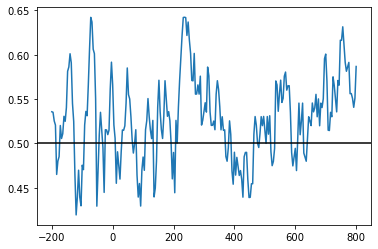

```python
plt.plot(times, mean_cv_scores)
plt.axhline(y = 0.5, c = "black")
```

### 3)

Is pairwise classification of subjective experience possible? Any surprises in the classification accuracies, i.e. how does the classification score fore PAS 1 vs 4 compare to the classification score for PAS 1 vs 2?

Well, it is possible to achieve accuracies way above chance, however they are not that high and only at quite specific timestamps (After 200 ms, before 250 ms). Quite surprising that classifying Pas 1 vs 4 has basically the same maximum accuracy as classifying PAS 1 vs 2.

## Exercise 3

Do a Support Vector Machine Classification on all four PAS-ratings

### 1)

Do a Support Vector Machine Classification

#### 3 1) i.

First equalize the number of targets using the function associated with each PAS-rating using the function associated with Exercise 3.1.i

```python
def equalize_targets(data, y):
    np.random.seed(7)
    targets = np.unique(y)
    counts = list()
    indices = list()
    for target in targets:
        counts.append(np.sum(y == target))
        indices.append(np.where(y == target)[0])
    min_count = np.min(counts)
    first_choice = np.random.choice(indices[0], size=min_count, replace=False)
    second_choice = np.random.choice(indices[1], size=min_count, replace=False)
    third_choice = np.random.choice(indices[2], size=min_count, replace=False)
    fourth_choice = np.random.choice(indices[3], size=min_count, replace=False)

    new_indices = np.concatenate((first_choice, second_choice,
                                 third_choice, fourth_choice))
    new_y = y[new_indices]
    new_data = data[new_indices, :, :]

    return new_data, new_y
```

```python
data_equal, y_equal = equalize_targets(data, y)
```

#### 3 1) ii.

Run two classifiers, one with a linear kernel and one with a radial basis (other options should be left at their defaults) - the number of features is the number of sensors multiplied the number of samples. Which one is better predicting the category?

```python
from sklearn.svm import SVC
svc_lin = SVC(kernel = "linear", random_state = 12)
svc_rbf = SVC(kernel = "rbf", random_state = 12)

x_data = data_equal.reshape(data_equal.shape[0],-1)
scaler = StandardScaler()
x_data = scaler.fit_transform(x_data)

svc_lin.fit(x_data, y_equal)
svc_rbf.fit(x_data, y_equal)

print("Mean accuracy of SVM with linear kernel is",svc_lin.score(x_data, y_equal), ". Mean accuracy of SVM with RBF kernel is",svc_rbf.score(x_data, y_equal).round(5))
```

```
Mean accuracy of SVM with linear kernel is 1.0 . Mean accuracy of SVM with RBF kernel is 0.98737
```

#### 3 1) iii.

Run the sample-by-sample analysis (similar to Exercise 2.2.v) with the best kernel (from Exercise 3.1.ii). Make a plot with time on the x-axis and classification score on the y-axis with a horizontal line at the chance level (what is the chance level for this analysis?)

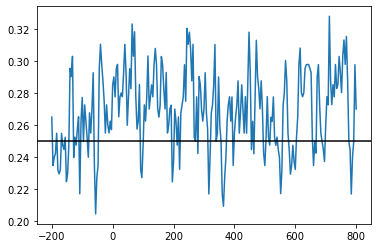

```python
svc_lin = SVC(kernel = "linear", random_state = 12)

cv_scores = np.zeros((data_equal.shape[2], 5))
mean_cv_scores = np.zeros(data_equal.shape[2])

for i in range(data_equal.shape[2]):
    x_data = data_equal[:,:,i]
    scaler = StandardScaler()
    x_data = scaler.fit_transform(x_data)
    cv_scores[i,:] = cross_val_score(svc_lin, x_data[:,:], y_equal, cv=5)
    mean_cv_scores[i] = np.mean(cv_scores[i,:])


plt.plot(times, mean_cv_scores)
plt.axhline(y = 0.25, c = "black")
```

#### 3 1) iv.

Is classification of subjective experience possible at around 200-250 ms?

Around 200-250 ms the support vector machine classification with a linear kernel has about 25-32% accuracy. Most of the time this is above chance so it is possible to predict subjective experience, but not very well. As comparison, even though the classifier with the RBF kernel performed worse in the previous exercise, it actually performs better than the linear kernel in the area 200-250 ms as can be seen below, with accuracy ratings ranging from 27-34%.

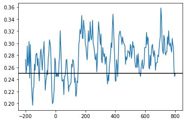

```python
svc_rbf = SVC(kernel = "rbf", random_state = 12)

cv_scores = np.zeros((data_equal.shape[2], 5))
mean_cv_scores = np.zeros(data_equal.shape[2])

for i in range(data_equal.shape[2]):
    x_data = data_equal[:,:,i]
    scaler = StandardScaler()
    x_data = scaler.fit_transform(x_data)
    cv_scores[i,:] = cross_val_score(svc_rbf, x_data[:,:], y_equal, cv=5)
    mean_cv_scores[i] = np.mean(cv_scores[i,:])


plt.plot(times, mean_cv_scores)
plt.axhline(y = 0.25, c = "black")
```

### 2)

Finally, split the equalized data set (with all four ratings) into a training part and test part, where the test part if 30 % of the trials. Use `train_test_split` from `sklearn.model_selection`

```python
from sklearn.model_selection import train_test_split

x_train, x_test, y_train, y_test = train_test_split(data_equal, y_equal, test_size = 0.3, random_state = 12, stratify = y_equal)
```

```python
x_train = x_train.reshape(x_train.shape[0],-1)
x_test = x_test.reshape(x_test.shape[0],-1)

scaler = StandardScaler()
x_train_trans = scaler.fit_transform(x_train)
x_test_trans = scaler.transform(x_test)
```

#### 3 2) i.

Use the kernel that resulted in the best classification in Exercise 3.1.ii and `fit`the training set and `predict` on the test set. This time your features are the number of sensors multiplied by the number of samples.

```python
from sklearn.svm import SVC
svc_lin = SVC(kernel = "linear", random_state = 24)

svc_lin.fit(x_train_trans, y_train)

y_pred_lin = svc_lin.predict(x_test_trans)
```

#### 3 2) ii.

Create a *confusion matrix*. It is a 4x4 matrix. The row names and the column names are the PAS-scores. There will thus be 16 entries. The PAS1xPAS1 entry will be the number of actual PAS1, $y_{pas1}$ that were predicted as PAS1, $\hat y_{pas1}$. The PAS1xPAS2 entry will be the number of actual PAS1, $y_{pas1}$ that were predicted as PAS2, $\hat y_{pas2}$ and so on for the remaining 14 entries. Plot the matrix

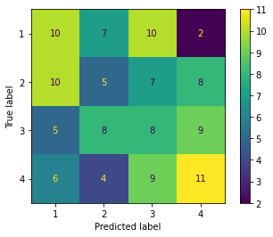

```python
from sklearn.metrics import ConfusionMatrixDisplay
ConfusionMatrixDisplay.from_predictions(y_test, y_pred_lin)
plt.show()
```

#### 3 2) iii.

Based on the confusion matrix, describe how ratings are misclassified and if that makes sense given that ratings should measure the strength/quality of the subjective experience. Is the classifier biased towards specific ratings?

```python
unique_y, y_count = np.unique(y_test, return_counts=True)
unique_pred_y, pred_y_count = np.unique(y_pred_lin, return_counts=True)
true_y = dict(zip(unique_y, y_count))
pred_y = dict(zip(unique_pred_y, pred_y_count))
print("Unique counts for the true labels:", true_y)
print("Unique counts for the predicted labels:", pred_y)
```

```
Unique counts for the true labels: {1: 29, 2: 30, 3: 30, 4: 30}
Unique counts for the predicted labels: {1: 31, 2: 24, 3: 34, 4: 30}
```

For all different PAS-ratings it seems that labels are most often misclassified as the PAS-ratings that are closest to it, e.g. PAS 2 misclassified as PAS 1 or 3, or PAS 4 misclassified as 3. However, this tendency does not hold true for everything. Also the classifier seems to be biased towards PAS 3. It predicts 28.57% of the test data to be PAS 3, while only 25.21% of the data is actually PAS 3.

Out of pure curiosity I will see what the results would have been for the RBF kernel.

```python
from sklearn.svm import SVC
svc_rbf = SVC(kernel = "rbf", random_state = 24)

svc_rbf.fit(x_train_trans, y_train)

y_pred_rbf = svc_rbf.predict(x_test_trans)
```

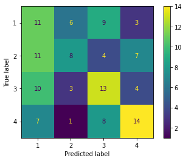

```python
from sklearn.metrics import ConfusionMatrixDisplay
ConfusionMatrixDisplay.from_predictions(y_test, y_pred_rbf)
plt.show()
```

```python
unique_y, y_count = np.unique(y_test, return_counts=True)
unique_pred_y, pred_y_count = np.unique(y_pred_rbf, return_counts=True)
true_y = dict(zip(unique_y, y_count))
pred_y = dict(zip(unique_pred_y, pred_y_count))
print("Unique counts for the true labels:", true_y)
print("Unique counts for the predicted labels:", pred_y)
```

```
Unique counts for the true labels: {1: 29, 2: 30, 3: 30, 4: 30}
Unique counts for the predicted labels: {1: 39, 2: 18, 3: 34, 4: 28}
```

RBF kernel seems to be highly biased towards PAS 1, so not necessarily a better result. As a last remark I suspect that the classifiers are highly influenced by the random_state given to them, perhaps indicating unstable and not that trustworthy models.